# General

#### General

The data is for **Orlando Police Department dispatch calls** rather than actual crimes. The data was obtained from the [Code for Orlando data sources website](http://www.codefororlando.com/data-sources/)

**To safeguard citizens' privacy, each of the individual locations was randomly dithered so that none of the results shown is an exact location but rather an approximate one.**

Either type a location's address or click on the map to obtain results around that location.

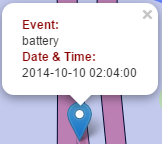

#### Bar plots

The bar plots (and the density maps and the summary) are faceted according to the input selection. In order to keep the tables readable, the top six crime types are used.

The following shows a result of crimes on Mondays, Wednesdays, and Fridays that took place during the early morning and evening time periods, faceted by day of the week

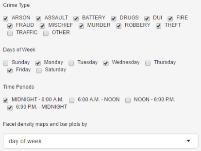

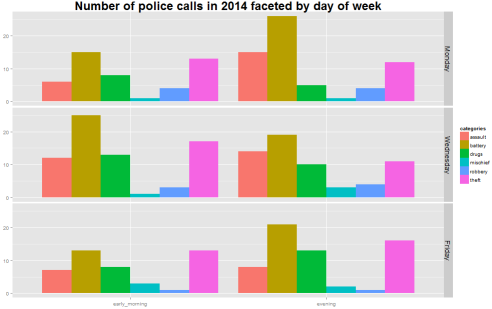

The same crime set, now faceted by time of day

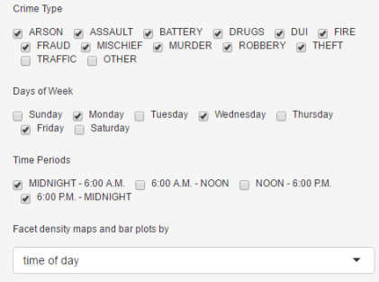

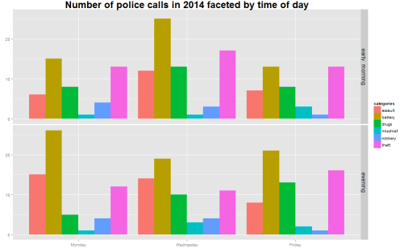

#### Density maps

The density maps take a few seconds to display. They are faceted similarly to the way the bar plots are.

[figure not shown]

#### Table

The Table tab does what one expects it to: tabulate the crime types, faceted in the same way the bar plots are.